# RanCh: A package for abstract discrete *Ran*dom *Ch*oice analysis

## Context effects

### Displaying context effects

Just as we can display cross-sections of a RCS consistent with regularity and the multiplicative inequality, we can display cross-sections of regions defined by various context effects.

Suppose we have similar objects $x$ and $y$ and an object $z$ that is dissimilar to both $x$ and $y$. The function `similarity_X3` constructs cross sections of six regions associated with binary-ternary similarity effects. The function takes as arguments the binary choice probabilities $p(x,z)$ and $p(y,z)$. For each of six types of similarity effect, it returns a region (in the form of a polygon) defining the set of ternary chocie probabilities consistent with $p(x,z)$, $p(y,z)$ and the type of similarity effect in question.

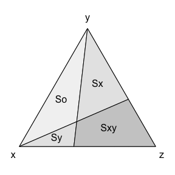

```r
S <- similarity_X3(pxz = 0.6, pyz = 0.4)
triplot(label=c('x', 'y', 'z')) # Set up ternary plot, with labels and grid
polygon(tritrafo(S$So), col=grey(0.95)); text(tritrafo(colMeans(S$So)), 'So')
polygon(tritrafo(S$Sx), col=grey(0.9)); text(tritrafo(colMeans(S$Sx)), 'Sx')
polygon(tritrafo(S$Sy), col=grey(0.9)); text(tritrafo(colMeans(S$Sy)), 'Sy')
polygon(tritrafo(S$Sxy), col=grey(0.8)); text(tritrafo(colMeans(S$Sxy)), 'Sxy')
```

If the objects $x$, $y$ and $z$ do not correpond to the first, second and third baycentric coordinates that we wish to plot, we can always permute the regions returned by `similarity_X3` accordingly. Suppose we want to plot in a barycentric coordinate system where the three coordinates correspond to the ternary choices probabilities of $a$, $b$ and $c$, but here $b$ is the dissimilar object and we want to show the region where there is an effect with $a$ as target, $c$ as decoy and $b$ as competitor.

[figure not shown]

```r
triplot(label=c('a', 'b', 'c')) # Set up ternary plot, with labels and grid
Sacb <- S$Sxyz[, c(1, 3, 2)]
polygon(tritrafo(Sacb), col=grey(0.95))
text(tritrafo(colMeans(Sacb)), 'Sacb')
```

We now show some compromise effect regions. Suppose that $x$ and $z$ are extreme objects and that $y$ is a between (or compromise) object. The following code computes six cross-sections of compromise regions and displays the regions `Co`, where there is no compromise effect; `Cx`, where there is a one-sided compromise effect with $y$ as target, $x$ as competitor and $z$ as decoy; `Cz`, where there is a one-sided compromise effect with $y$ as target; $z$ as competitor and $x$ as decoy; `Cxz`, where there is a two-sided compromise effect.

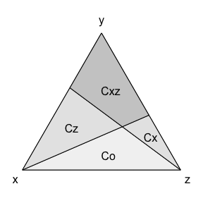

```r
C <- compromise_X3(pyx = 0.6, pyz = 0.4)
triplot(label=c('x', 'y', 'z')) # Set up ternary plot
polygon(tritrafo(C$Co), col=grey(0.95)); text(tritrafo(colMeans(C$Co)), 'Co')
polygon(tritrafo(C$Cx), col=grey(0.9)); text(tritrafo(colMeans(C$Cx)), 'Cx')
polygon(tritrafo(C$Cz), col=grey(0.9)); text(tritrafo(colMeans(C$Cz)), 'Cz')
polygon(tritrafo(C$Cxz), col=grey(0.8)); text(tritrafo(colMeans(C$Cxz)), 'Cxz')
```

### Checking for context effects

We can also check specific RCDs, arising from direct specification, simulation, or observed choice proportions, to see if they exhibit context effects. Below, we simulate 500 variates from the uniform distribution on the 2-simplex. For each draw, we construct a RCD by setting the ternary choice probability to the random draw and supplying the (constant) binary choice probabilities used in the examples illustrating `similarity_X3` and `compromise_X3`—the probabilities in the two examples are consistent with each other. Then we create two graphics. In the first, we plot only those ternary probabilities that, together with the fixed binary probabilities, satisfy the two-sided similarity effect. In the second, we plot the points that satisfy the two-sided compromise effect. We note that the retained points fall in the regions `Sxy` and `Cxz` from the `similarity_X3` and `compromise_X3` examples, respectively.

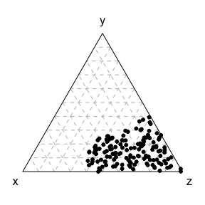

```r
n <- 500
filt1 <- vector('logical', n); filt2 <- vector('logical', n)
p <- rDirichlet(n, c(1, 1, 1)) # Uniform distribution on 2-simplex
for (i in 1:n) {
  P <- create_P3(0.4, 0.4, 0.6, p[i,1], p[i,2])
  filt1[i] <- similarity(P, target=1, decoy=2, competitor=3, two_sided=TRUE)
  filt2[i] <- compromise(P, target=2, decoy=3, competitor=1, two_sided=TRUE)
}
triplot(label=c('x', 'y', 'z'))
points(tritrafo(p[filt1, ]), pch=20)
```

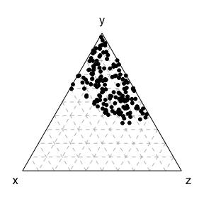

```r
triplot(label=c('x', 'y', 'z'))
points(tritrafo(p[filt2, ]), pch=20)
```

## Inference

Suppose we have a count matrix $N$ for a discrete choice experiment and an RCS matrix $P$ with the same dimensions as $N$. Then the likelihood function for data $N$, evaluated at $P$, is a product of multinomial likelihoods, each likelihood factor corresponding to a particular choice set. Each choice set corresponds in turn to a particular row of both $N$ and $P$.

We can complete a Bayesian model by providing a conjugate prior, where the rows of $P$ are independent Dirichlet. This leads to closed form solutions to the posterior distribution of $P$ and the marginal likelihood, which is the integral of the likelihood with respect to the prior distribution of $P$. The marginal likelihood is also the marginal probability of seeing the data $N$; it is, in a sense, an out-of-sample prediction record of the model for the data $N$.

The posterior distribution takes the same form as the prior: rows are *a posteriori* independent and Dirichlet. Here the matrix of Dirichlet parameters is `post_Alpha`, the sum of `prior_Alpha` and `N_bce`; see the Wikipedia page on the [Dirichlet distribution](https://en.wikipedia.org/wiki/Dirichlet_distribution) for details.

### High posterior density curves

The code below constructs and then displays 0.90 High Posterior Density (HPD) regions for four choice probability vectors. Regions for the three binary choice probabilities are the thick-line intervals on the three sides of the triangle. The region for the ternary choice probability vector is the green shape in the interior of the triangle.

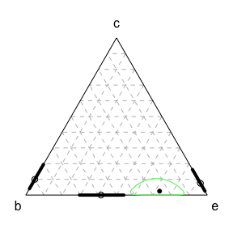

```r
library(klaR)
prior_Alpha <- RCS_scalar_alpha_prior(2.0, ncol(N_bce))
post_Alpha <- prior_Alpha + N_bce
HD3 <- Dir2_3_HD_region(post_Alpha, 0.9, c(1,2,3))
triplot(label=c('b', 'c', 'e'))               # Set up ternary plot
lines(tritrafo(HD3$HD12), lwd=4)              # Plot three binaries
lines(tritrafo(HD3$HD23), lwd=4)
lines(tritrafo(HD3$HD13), lwd=4)
polygon(tritrafo(HD3$HD123), border='lightgreen') # Plot ternary
plot_P3(P_bce)                           # Plot proportions from data
```

### Marginal likelihoods for some simple models

We can also compute the log marginal likelihood for various simple models, as follows.

```r
N = MMS_2019_counts['Colours',,]
n_objects = ncol(N)

# Zero parameter models
print(log_L_DCE_multinomial(P_uniform(n_objects), N, categorical=TRUE))
  [1] -1060.825
print(log_L_DCE_Dir_mult(RCS_uniform_prior(n_objects), N, categorical=TRUE))
  [1] -947.5373

# One parameter models
print(log_L_DCE_Dir_mult(RCS_scalar_alpha_prior(2.0, n_objects), N,
                         categorical=TRUE))
  [1] -955.2024

# n-parameter models
print(log_L_DCE_Dir_mult(RCS_vector_alpha_prior(4.0, c(1.0, 2.0, 1.0, 2.0, 1.0)),
                         N, categorical=TRUE))
  [1] -939.3222
```

These marginal likelihoods serve as useful benchmarks.

## References

Falmagne, J. C. 1978. “A Representation Theorem for Finite Random Scale Systems.” *Journal of Mathematical Psychology* 18: 52–72.

McCausland, William J., and A. A. J. Marley. 2013. “Prior Distributions for Random Choice Structures.” *Journal of Mathematical Psychology* 57: 78–93.

Regenwetter, M., J. Dana, and C. P. Davis-Stober. 2011. “Transitivity of Preferences.” *Psychological Review* 118: 42–56.

Sattath, S., and A. Tversky. 1976. “Unite and Conquer: A Multiplicative Inequality for Choice Probabilities.” *Econometrica* 44: 79–89.

Tversky, A. 1972. “Choice by Elimination.” *Journal of Mathematical Psychology* 9: 341–67.

Tversky, Amos. 1972. “Elimination by Aspects: A Theory of Choice.” *Psychological Review* 79 (4): 281–99.